# Model in R.

# Material.

Have only two points, one test and one train, of material==3. Drop.

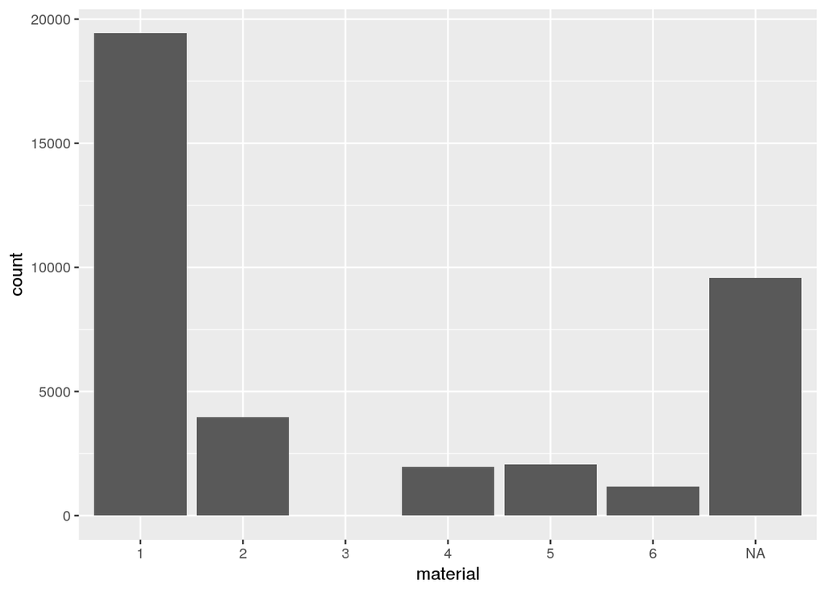

```r
qplot(material, data=overall_data)
```

```r
idx <- with(overall_data, material == 3)
overall_data$material[idx] <- NA
```

# Build year

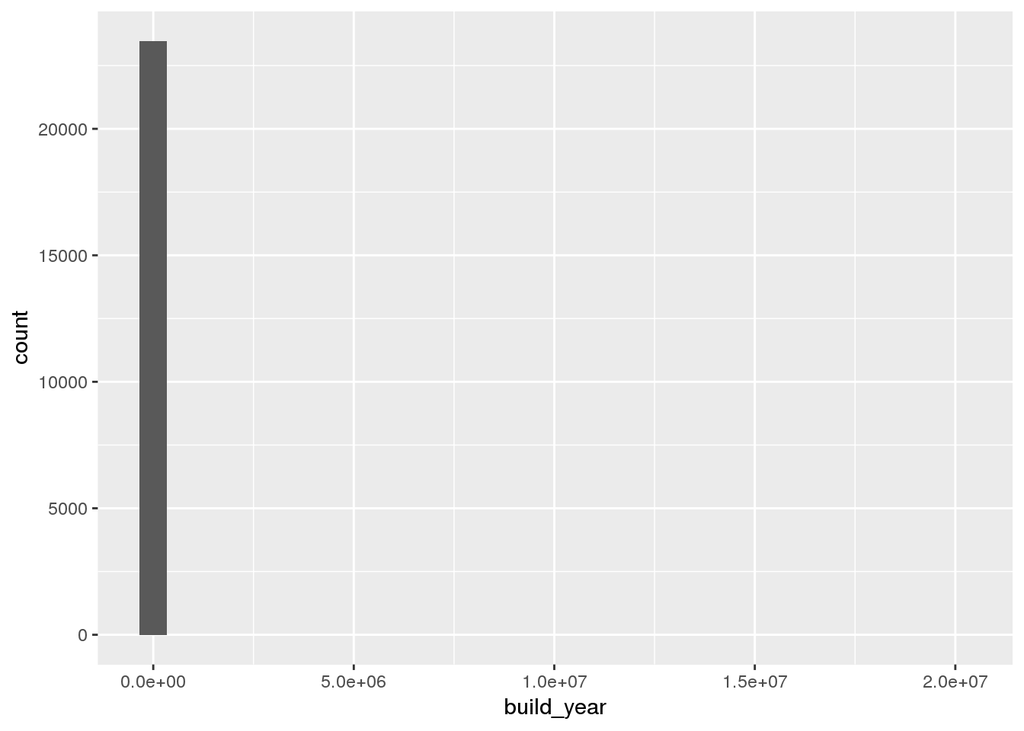

```
## subset(overall_data, build_year < 1860 | build_year > 2017)$build_year
##        0        1        2        3       20       71      215     1691
##      899      555        1        2        1        1        2        1
##     2018     2019     4965 20052009
##       31        5        1        1
```

## num rooms

Less than 1 room is probably incorrect.

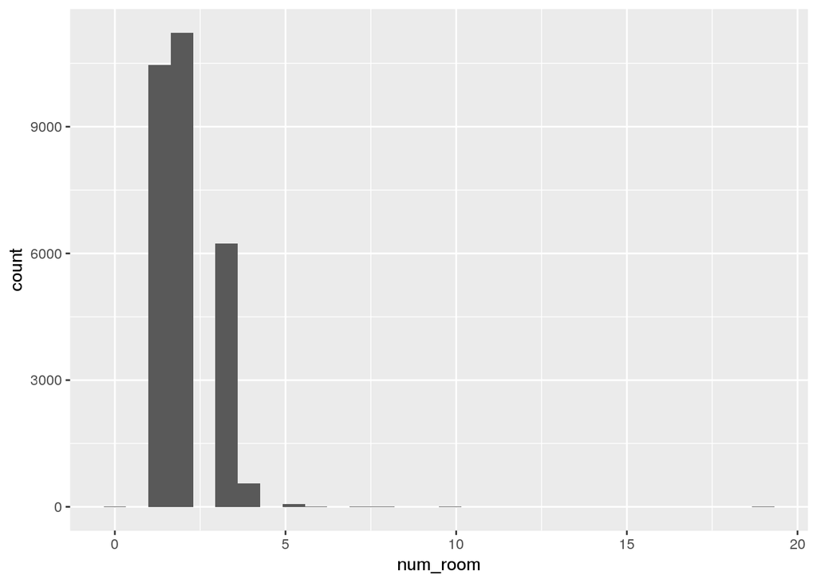

## kitchen sq

Have some kitchen sq that look like build years. Use those to guess a build year. Have many that look the same size (or bigger than) the life or full sq. Clear those.

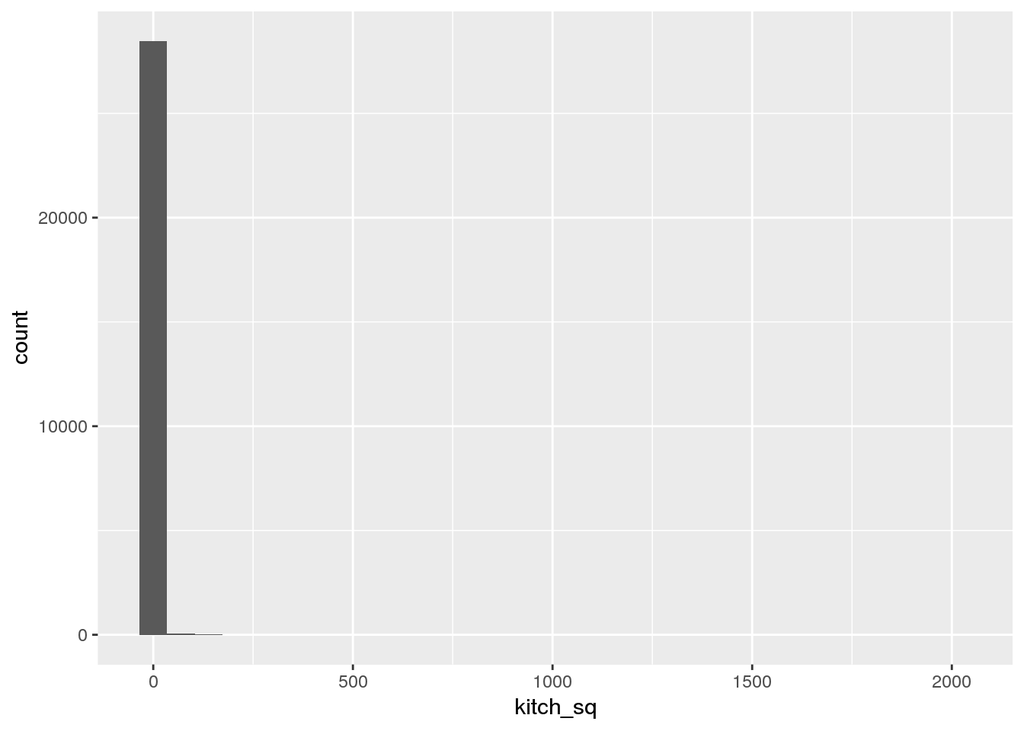

## State

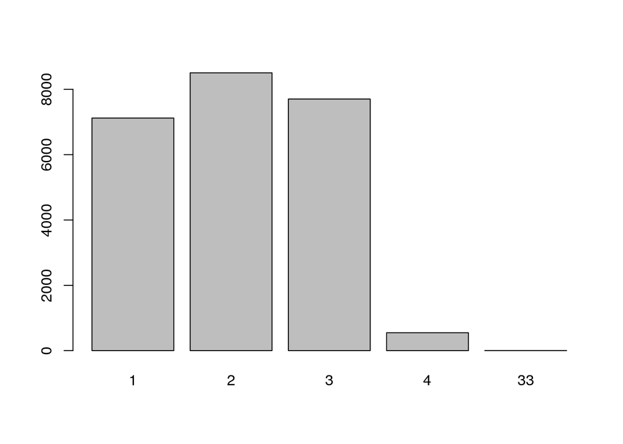

# Impute missing values.

Add a value-is-missing column and remove near-zero variance columns, in prep for imputing values and transforming.

```
## [1] "  add_isna_col processing full_sq"
## [1] "  add_isna_col processing life_sq"
## [1] "  add_isna_col processing floor"
## [1] "  add_isna_col processing max_floor"
## [1] "  add_isna_col processing material"
## [1] "  add_isna_col processing build_year"
## [1] "  add_isna_col processing num_room"
## [1] "  add_isna_col processing kitch_sq"
## [1] "  add_isna_col processing state"
## [1] "  add_isna_col processing product_type"
## [1] "  add_isna_col processing preschool_quota"
## [1] "  add_isna_col processing school_quota"
## [1] "  add_isna_col processing hospital_beds_raion"
## [1] "  add_isna_col processing raion_build_count_with_material_info"
## [1] "  add_isna_col processing build_count_block"
```

[output cut: 39 more lines]

## Impute and transform

Use caret::preProcess to impute.

```
## [1] "after imputation, have 0 NAs in train data"
##  [1] "power tranformation columns are"
##  [2] "area_m"
##  [3] "raion_popul"
##  [4] "green_zone_part"
##  [5] "children_preschool"
##  [6] "children_school"
##  [7] "full_all"
##  [8] "male_f"
##  [9] "female_f"
## [10] "young_all"
## [11] "young_male"
## [12] "young_female"
## [13] "work_all"
## [14] "work_male"
```

[output cut: 75 more lines]

```
## [1] "after preprocessor step, have 0 NAs in train_i data"
```

```
## [1] "after preprocessor step, have 0 NAs in test_i data"
```

```
## [1] "after preprocessor step, have 0 NAs in validation_i data"
```

```
## [1] "after preprocessor step, have 7662 NAs in submission_test_i data"
```

# Model

```
##             used   (Mb) gc trigger   (Mb)  max used   (Mb)
## Ncells   3645573  194.7    6861544  366.5   6861544  366.5
## Vcells 170792418 1303.1  393342159 3001.0 393341417 3001.0
```

```
##             used   (Mb) gc trigger   (Mb)  max used   (Mb)
## Ncells   3646845  194.8    6861544  366.5   6861544  366.5
## Vcells 170794368 1303.1  393342159 3001.0 393341417 3001.0
```

```
##             used   (Mb) gc trigger   (Mb)  max used   (Mb)
## Ncells   3648296  194.9    6861544  366.5   6861544  366.5
## Vcells 170835092 1303.4  393342159 3001.0 393341417 3001.0
```

# Validation

```
## [1] "train score: 0.442195"
```

```
## [1] "test score: 0.476508"
```

```
## [1] "validation score: 0.465015"
```